# FullCode_Bank Churn Prediction

## Data Preprocessing

### Dummy Variable Creation

```python
# performing one hot encoding on categorical columns
data = pd.get_dummies(data,columns=data.select_dtypes(include=["object"]).columns.tolist(),drop_first=True)
data = data.astype(float)
data.head()
```

|  | CreditScore | Age | Tenure | Balance | NumOfProducts | HasCrCard | IsActiveMember | EstimatedSalary | Exited | Geography_Germany | Geography_Spain | Gender_Male |
| --- | --- | --- | --- | --- | --- | --- | --- | --- | --- | --- | --- | --- |
| 0 | 619.0 | 42.0 | 2.0 | 0.00 | 1.0 | 1.0 | 1.0 | 101348.88 | 1.0 | 0.0 | 0.0 | 0.0 |
| 1 | 608.0 | 41.0 | 1.0 | 83807.86 | 1.0 | 0.0 | 1.0 | 112542.58 | 0.0 | 0.0 | 1.0 | 0.0 |
| 2 | 502.0 | 42.0 | 8.0 | 159660.80 | 3.0 | 1.0 | 0.0 | 113931.57 | 1.0 | 0.0 | 0.0 | 0.0 |
| 3 | 699.0 | 39.0 | 1.0 | 0.00 | 2.0 | 0.0 | 0.0 | 93826.63 | 0.0 | 0.0 | 0.0 | 0.0 |
| 4 | 850.0 | 43.0 | 2.0 | 125510.82 | 1.0 | 1.0 | 1.0 | 79084.10 | 0.0 | 0.0 | 1.0 | 0.0 |

### Train-validation-test Split

```python
# Droping target col frm X and Y as the target data
X = data.drop(['Exited'],axis=1)
y = data['Exited']
```

```python
X_large, X_test, y_large, y_test = train_test_split(X, y, test_size = 0.2, random_state = 42,stratify=y,shuffle = True)
```

```python
X_train, X_val, y_train, y_val = train_test_split(X_large, y_large, test_size = 0.25, random_state = 42,stratify=y_large, shuffle = True)
```

```python
print(X_train.shape, X_val.shape, X_test.shape)
```

```
(6000, 11) (2000, 11) (2000, 11)
```

```python
print(y_train.shape, y_val.shape, y_test.shape)
```

```
(6000,) (2000,) (2000,)
```

### Data Normalization

#### Scaling numberical value

```python
# Numerical features to scale
numerical_features = ['CreditScore', 'Age', 'Tenure', 'Balance', 'NumOfProducts', 'EstimatedSalary']

# Initialize StandardScaler
scaler = StandardScaler()

# Fit and transform on training data
X_train[numerical_features] = scaler.fit_transform(X_train[numerical_features])

# Transform validation and test data using the same scaler
X_val[numerical_features] = scaler.transform(X_val[numerical_features])
X_test[numerical_features] = scaler.transform(X_test[numerical_features])
```

## Model Building

### Model Evaluation Criterion

**creating a function for plotting the confusion matrix**

```python
def make_confusion_matrix(actual_targets, predicted_targets):
    """
    To plot the confusion_matrix with percentages

    actual_targets: actual target (dependent) variable values
    predicted_targets: predicted target (dependent) variable values
    """
    cm = confusion_matrix(actual_targets, predicted_targets)
    labels = np.asarray(
        [
            ["{0:0.0f}".format(item) + "\n{0:.2%}".format(item / cm.flatten().sum())]
            for item in cm.flatten()
        ]
    ).reshape(cm.shape[0], cm.shape[1])

    plt.figure(figsize=(6, 4))
    sns.heatmap(cm, annot=labels, fmt="")
    plt.ylabel("True label")
    plt.xlabel("Predicted label")
```

Let's create two blank dataframes that will store the recall values for all the models we build.

```python
# Recall is considered because cost of false nagtive is high.
train_metric_df = pd.DataFrame(columns=["recall"])
valid_metric_df = pd.DataFrame(columns=["recall"])
```

NOTE - We are considering RECALL as our important parameter because we need minimum False negative. In other words if model predicts a customer wont churn but the customer churns then it would be loss of business for bank. we want to avoid such scenarios.

### Neural Network with SGD Optimizer

```python
backend.clear_session()
#Fixing the seed for random number generators so that we can ensure we receive the same output everytime
np.random.seed(2)
random.seed(2)
tf.random.set_seed(2)
```

```python
#Initializing the neural network
model_0 = Sequential()
# Adding the input layer with 64 neurons and relu as activation function
model_0.add(Dense(64, activation='relu', input_dim = X_train.shape[1]))
# Adding Hidden Layer
model_0.add(Dense(32, activation='relu'))
# Adding Output layer
model_0.add(Dense(1, activation = 'sigmoid'))
```

```python
#Using SGD as the optimizer.
optimizer = tf.keras.optimizers.SGD(0.001)
# metric = 'accuracy'
metric = keras.metrics.Recall()
# metric = keras.metrics.Precision()
# metric = keras.metrics.F1Score()
```

```python
## code to compile the model with binary cross entropy as loss function and recall as the metric.
model_0.compile(loss='binary_crossentropy',optimizer=optimizer,metrics=[metric])
```

```python
model_0.summary()
```

```
Model: "sequential"
```

```
┏━━━━━━━━━━━━━━━━━━━━━━━━━━━━━━━━━━━━━━┳━━━━━━━━━━━━━━━━━━━━━━━━━━━━━┳━━━━━━━━━━━━━━━━━┓
┃ Layer (type)                         ┃ Output Shape                ┃         Param # ┃
┡━━━━━━━━━━━━━━━━━━━━━━━━━━━━━━━━━━━━━━╇━━━━━━━━━━━━━━━━━━━━━━━━━━━━━╇━━━━━━━━━━━━━━━━━┩
│ dense (Dense)                        │ (None, 64)                  │             768 │
├──────────────────────────────────────┼─────────────────────────────┼─────────────────┤
│ dense_1 (Dense)                      │ (None, 32)                  │           2,080 │
├──────────────────────────────────────┼─────────────────────────────┼─────────────────┤
│ dense_2 (Dense)                      │ (None, 1)                   │              33 │
└──────────────────────────────────────┴─────────────────────────────┴─────────────────┘
```

```
 Total params: 2,881 (11.25 KB)
```

```
 Trainable params: 2,881 (11.25 KB)
```

```
 Non-trainable params: 0 (0.00 B)
```

Above is the summary of the model that we are going to user. Input layer will have 64 neurons , hidden layer will have 32 neurons and output will be 1 since its a binary classification.

```python
# Fitting the ANN

history_0 = model_0.fit(
    X_train, y_train,
    batch_size=32,
    validation_data=(X_val,y_val),
    epochs=50,
    verbose=1
)
```

```
188/188 ━━━━━━━━━━━━━━━━━━━━ 1s 4ms/step - loss: 0.6778 - recall: 0.3018 - val_loss: 0.6147 - val_recall: 0.0590
188/188 ━━━━━━━━━━━━━━━━━━━━ 1s 3ms/step - loss: 0.5998 - recall: 0.0343 - val_loss: 0.5677 - val_recall: 0.0000e+00
188/188 ━━━━━━━━━━━━━━━━━━━━ 1s 3ms/step - loss: 0.5546 - recall: 0.0013 - val_loss: 0.5401 - val_recall: 0.0000e+00
188/188 ━━━━━━━━━━━━━━━━━━━━ 1s 3ms/step - loss: 0.5269 - recall: 0.0000e+00 - val_loss: 0.5229 - val_recall: 0.0000e+00
188/188 ━━━━━━━━━━━━━━━━━━━━ 1s 3ms/step - loss: 0.5092 - recall: 0.0000e+00 - val_loss: 0.5118 - val_recall: 0.0000e+00
188/188 ━━━━━━━━━━━━━━━━━━━━ 1s 3ms/step - loss: 0.4973 - recall: 0.0000e+00 - val_loss: 0.5040 - val_recall: 0.0000e+00
188/188 ━━━━━━━━━━━━━━━━━━━━ 1s 3ms/step - loss: 0.4888 - recall: 0.0000e+00 - val_loss: 0.4981 - val_recall: 0.0000e+00
188/188 ━━━━━━━━━━━━━━━━━━━━ 1s 3ms/step - loss: 0.4822 - recall: 0.0000e+00 - val_loss: 0.4934 - val_recall: 0.0000e+00
188/188 ━━━━━━━━━━━━━━━━━━━━ 1s 4ms/step - loss: 0.4769 - recall: 0.0000e+00 - val_loss: 0.4894 - val_recall: 0.0000e+00
188/188 ━━━━━━━━━━━━━━━━━━━━ 1s 5ms/step - loss: 0.4725 - recall: 0.0000e+00 - val_loss: 0.4858 - val_recall: 0.0000e+00
188/188 ━━━━━━━━━━━━━━━━━━━━ 1s 5ms/step - loss: 0.4686 - recall: 0.0000e+00 - val_loss: 0.4825 - val_recall: 0.0000e+00
188/188 ━━━━━━━━━━━━━━━━━━━━ 1s 4ms/step - loss: 0.4650 - recall: 0.0000e+00 - val_loss: 0.4795 - val_recall: 0.0000e+00
188/188 ━━━━━━━━━━━━━━━━━━━━ 1s 3ms/step - loss: 0.4618 - recall: 0.0000e+00 - val_loss: 0.4767 - val_recall: 0.0000e+00
188/188 ━━━━━━━━━━━━━━━━━━━━ 1s 3ms/step - loss: 0.4588 - recall: 0.0000e+00 - val_loss: 0.4740 - val_recall: 0.0000e+00
188/188 ━━━━━━━━━━━━━━━━━━━━ 1s 3ms/step - loss: 0.4560 - recall: 0.0000e+00 - val_loss: 0.4715 - val_recall: 0.0000e+00
188/188 ━━━━━━━━━━━━━━━━━━━━ 1s 3ms/step - loss: 0.4533 - recall: 0.0000e+00 - val_loss: 0.4691 - val_recall: 0.0000e+00
188/188 ━━━━━━━━━━━━━━━━━━━━ 1s 3ms/step - loss: 0.4508 - recall: 0.0000e+00 - val_loss: 0.4668 - val_recall: 0.0000e+00
188/188 ━━━━━━━━━━━━━━━━━━━━ 1s 3ms/step - loss: 0.4484 - recall: 0.0000e+00 - val_loss: 0.4646 - val_recall: 0.0000e+00
188/188 ━━━━━━━━━━━━━━━━━━━━ 1s 3ms/step - loss: 0.4461 - recall: 0.0000e+00 - val_loss: 0.4625 - val_recall: 0.0000e+00
188/188 ━━━━━━━━━━━━━━━━━━━━ 1s 3ms/step - loss: 0.4439 - recall: 0.0000e+00 - val_loss: 0.4605 - val_recall: 0.0000e+00
188/188 ━━━━━━━━━━━━━━━━━━━━ 1s 3ms/step - loss: 0.4419 - recall: 0.0000e+00 - val_loss: 0.4586 - val_recall: 0.0000e+00
188/188 ━━━━━━━━━━━━━━━━━━━━ 1s 3ms/step - loss: 0.4399 - recall: 0.0013 - val_loss: 0.4567 - val_recall: 0.0025
188/188 ━━━━━━━━━━━━━━━━━━━━ 1s 3ms/step - loss: 0.4380 - recall: 0.0013 - val_loss: 0.4550 - val_recall: 0.0025
188/188 ━━━━━━━━━━━━━━━━━━━━ 1s 2ms/step - loss: 0.4362 - recall: 0.0015 - val_loss: 0.4533 - val_recall: 0.0049
188/188 ━━━━━━━━━━━━━━━━━━━━ 1s 3ms/step - loss: 0.4344 - recall: 0.0015 - val_loss: 0.4517 - val_recall: 0.0049
188/188 ━━━━━━━━━━━━━━━━━━━━ 1s 3ms/step - loss: 0.4328 - recall: 0.0032 - val_loss: 0.4502 - val_recall: 0.0049
188/188 ━━━━━━━━━━━━━━━━━━━━ 1s 3ms/step - loss: 0.4312 - recall: 0.0062 - val_loss: 0.4487 - val_recall: 0.0098
188/188 ━━━━━━━━━━━━━━━━━━━━ 1s 3ms/step - loss: 0.4297 - recall: 0.0064 - val_loss: 0.4473 - val_recall: 0.0098
188/188 ━━━━━━━━━━━━━━━━━━━━ 1s 3ms/step - loss: 0.4282 - recall: 0.0076 - val_loss: 0.4460 - val_recall: 0.0098
188/188 ━━━━━━━━━━━━━━━━━━━━ 2s 5ms/step - loss: 0.4268 - recall: 0.0092 - val_loss: 0.4447 - val_recall: 0.0147
188/188 ━━━━━━━━━━━━━━━━━━━━ 1s 4ms/step - loss: 0.4254 - recall: 0.0150 - val_loss: 0.4434 - val_recall: 0.0147
188/188 ━━━━━━━━━━━━━━━━━━━━ 1s 3ms/step - loss: 0.4241 - recall: 0.0180 - val_loss: 0.4423 - val_recall: 0.0197
188/188 ━━━━━━━━━━━━━━━━━━━━ 1s 3ms/step - loss: 0.4229 - recall: 0.0191 - val_loss: 0.4411 - val_recall: 0.0319
188/188 ━━━━━━━━━━━━━━━━━━━━ 1s 3ms/step - loss: 0.4217 - recall: 0.0219 - val_loss: 0.4401 - val_recall: 0.0369
188/188 ━━━━━━━━━━━━━━━━━━━━ 1s 3ms/step - loss: 0.4205 - recall: 0.0267 - val_loss: 0.4390 - val_recall: 0.0467
188/188 ━━━━━━━━━━━━━━━━━━━━ 1s 3ms/step - loss: 0.4194 - recall: 0.0322 - val_loss: 0.4380 - val_recall: 0.0541
188/188 ━━━━━━━━━━━━━━━━━━━━ 0s 3ms/step - loss: 0.4184 - recall: 0.0370 - val_loss: 0.4370 - val_recall: 0.0541
188/188 ━━━━━━━━━━━━━━━━━━━━ 1s 3ms/step - loss: 0.4173 - recall: 0.0505 - val_loss: 0.4361 - val_recall: 0.0614
188/188 ━━━━━━━━━━━━━━━━━━━━ 1s 3ms/step - loss: 0.4163 - recall: 0.0521 - val_loss: 0.4352 - val_recall: 0.0614
188/188 ━━━━━━━━━━━━━━━━━━━━ 1s 3ms/step - loss: 0.4153 - recall: 0.0598 - val_loss: 0.4343 - val_recall: 0.0663
188/188 ━━━━━━━━━━━━━━━━━━━━ 1s 3ms/step - loss: 0.4144 - recall: 0.0644 - val_loss: 0.4335 - val_recall: 0.0786
188/188 ━━━━━━━━━━━━━━━━━━━━ 1s 3ms/step - loss: 0.4134 - recall: 0.0706 - val_loss: 0.4326 - val_recall: 0.0835
188/188 ━━━━━━━━━━━━━━━━━━━━ 1s 3ms/step - loss: 0.4125 - recall: 0.0753 - val_loss: 0.4319 - val_recall: 0.0835
188/188 ━━━━━━━━━━━━━━━━━━━━ 1s 3ms/step - loss: 0.4117 - recall: 0.0816 - val_loss: 0.4311 - val_recall: 0.0860
188/188 ━━━━━━━━━━━━━━━━━━━━ 1s 3ms/step - loss: 0.4108 - recall: 0.0857 - val_loss: 0.4303 - val_recall: 0.0909
188/188 ━━━━━━━━━━━━━━━━━━━━ 1s 3ms/step - loss: 0.4100 - recall: 0.0925 - val_loss: 0.4296 - val_recall: 0.0909
188/188 ━━━━━━━━━━━━━━━━━━━━ 1s 3ms/step - loss: 0.4092 - recall: 0.0969 - val_loss: 0.4289 - val_recall: 0.0983
188/188 ━━━━━━━━━━━━━━━━━━━━ 1s 3ms/step - loss: 0.4084 - recall: 0.1115 - val_loss: 0.4282 - val_recall: 0.1057
188/188 ━━━━━━━━━━━━━━━━━━━━ 1s 5ms/step - loss: 0.4076 - recall: 0.1138 - val_loss: 0.4275 - val_recall: 0.1081
188/188 ━━━━━━━━━━━━━━━━━━━━ 1s 4ms/step - loss: 0.4068 - recall: 0.1244 - val_loss: 0.4269 - val_recall: 0.1179
```

**Loss function**

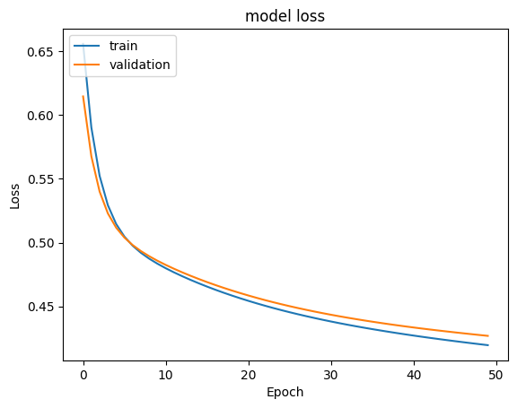

```python
#Plotting Train Loss vs Validation Loss
plt.plot(history_0.history['loss'])
plt.plot(history_0.history['val_loss'])
plt.title('model loss')
plt.ylabel('Loss')
plt.xlabel('Epoch')
plt.legend(['train', 'validation'], loc='upper left')
plt.show()
```

**Observations**